# Piloto Recomendador

GERENCIA DE INNOVACIÓN BI

Julio 2016

## Introducción

El recomedador de contenidos busca dar luz sobre el gran catálogo de contenidos que tenemos en la plataforma, ayudando al cliente a encontrar contenidos afines a él. Internamente usamos la información de audiencias y otra información de BI para calcular los contenidos más acordes a cada cliente (hogar) haciendo uso de algoritmos de *machine learning*. Es importante ser consciente que las recomendaciones se hacen sobre todo el hogar, así que en los hogares con varias personas os animamos a que compartáis las recomendaciones y recojáis el *feedback* de ellas.

Está previsto realizar modificaciones en las recomendaciones del hogar si se detecta comportamientos distintos por dispositivo y/o franja horario. De este modo, en un hogar donde por las mañanas el consumo de contenidos infantiles es mayor las recomendaciones de este tipo se mostrarían primero.

[figure not shown]

Para empezar, os mostramos la información de **audiencias VOD** que hemos recogido en el 2016, para que podáis comprobar el uso que estáis haciendo de la plataforma por tipo de dispositivo.

[interactive chart not shown]

(solo se muestran las categorías con al menos un contenido visto)

## Mi TV

Las recomendaciones **Mi TV**, son las recomendaciones generales del hogar, aquí podemos encontrar todo tipo de contenidos afines: Películas, series, documentales…

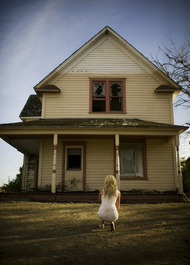

- Encerrada

[figure not shown]

- Los imprevistos del amor

[figure not shown]

- Vamos de polis

[figure not shown]

- Ahora o nunca

[figure not shown]

- El desconocido

[figure not shown]

- Felices 140

[figure not shown]

- Amor a segunda vista

[figure not shown]

- La teoría del todo

[figure not shown]

- Ted 2

[figure not shown]

- Rey gitano

## Tus gustos

**NOTA:** Los nombres de los gustos son temporales y se están diseñando unos nombres más vistosos y que no recuerden a los clásicos géneros.

#### También te puede interesar el suspense...

[figure not shown]

- No se lo digas a nadie

[figure not shown]

- Sospechoso cero

[figure not shown]

- The Blacklist

[figure not shown]

- American Psycho

[figure not shown]

- London Boulevard

[figure not shown]

- Mientras duermes

[figure not shown]

- El maquinista

[figure not shown]

- Breaking Bad

[figure not shown]

- Cleaner

[figure not shown]

- Cautivos

#### Porque ves dramas sociales...

[figure not shown]

[figure not shown]

- Truman

[figure not shown]

- La flaqueza del bolchevique

[figure not shown]

- Un otoño sin Berlín

[figure not shown]

- Les revenants

[figure not shown]

- Amama

[figure not shown]

- Import/Export

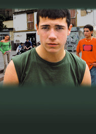

- 7 Vírgenes

[figure not shown]

- El capital humano

[figure not shown]

- Heli